# creative Assignment 4

Sara Arman

10/6/2020

```r
library(osmdata)
library(opentripplanner)
library(tidyverse)
library(sf)
library(ggthemes)
library(ggspatial)
library(raster)
```

## Loading Data

I am starting by following Carole’s code but instead loading Public School data from Analyze Boston, and filtering it to only include Roxbury (the neighborhood I am looking at for Studio).When I was doing public schools for all of Roxbury, there were 19 points which was taking my computer a really long time to load, so thank you so much to Mel for suggesting I only include a certain schools. I used Mel’s code to filter out to just elementary schools.

```r
Boston_Public <- st_read ("http://bostonopendata-boston.opendata.arcgis.com/datasets/1d9509a8b2fd485d9ad471ba2fdb1f90_0.geojson?outSR=%7B%22latestWkid%22%3A2249%2C%22wkid%22%3A102686%7D")
Roxbury_Public <- Boston_Public %>%
  filter (CITY == "Roxbury")
Roxbury_Public <- Boston_Public %>%
  filter (CITY == "Roxbury", SCH_TYPE == "ES")
```

```r
opq(bbox = 'Boston MA USA') %>%
  add_osm_feature(key = 'highway') %>%
  osmdata_xml(file = 'OTP/graphs/default/boston_streets.osm')
```

### I am transforming the data on to the MA plane.

```r
MA_state_plane <- "+proj=lcc +lat_1=41.71666666666667 +lat_2=42.68333333333333 +lat_0=41 +lon_0=-71.5 +x_0=200000 +y_0=750000 +ellps=GRS80 +units=m +no_defs"
boston_streets_features <- opq(bbox = 'Boston MA USA') %>%
  add_osm_feature(key = 'highway') %>%
  osmdata_sf()
boston_streets <- boston_streets_features$osm_lines %>%
  st_transform(crs = MA_state_plane)
```

### I am plotting the street data

I’ll get street data for Roxbury, Boston, MA.

```r
MA_state_plane <- "+proj=lcc +lat_1=41.71666666666667 +lat_2=42.68333333333333 +lat_0=41 +lon_0=-71.5 +x_0=200000 +y_0=750000 +ellps=GRS80 +units=m +no_defs"
rox_street_query <- opq(bbox = 'Roxbury MA USA')%>%
  add_osm_feature (key = 'highway')
rox_street_query %>%
  osmdata_xml (file = 'OTP/Graphs/Default/rox_streets.osm')
rox_street_features <- rox_street_query %>%
  osmdata_sf()
rox_streets <- rox_street_features$osm_lines %>%
  st_transform(crs=MA_state_plane)
```

### I am downloading Java and Open Trip Planner

```r
path_otp <- otp_dl_jar("OTP")
```

```r
path_data <- file.path(getwd(), "OTP")
path_otp <- paste(path_data, "otp.jar",sep = "/")
otp_build_graph(otp = path_otp, dir = path_data, memory = 1024)
```

```r
otp_setup(otp = path_otp, dir = path_data, memory =1024)
# Connect to opentripplanner
otpcon <- otp_connect()
```

### I am creating Isochrones

Using Carole’s code, I am plotting and measuring the areas that are within a five-minute walk and a five-minute drive of the Public Elementary Schools in Roxbury.

```r
iso_5min_walk <-
  otp_isochrone(otpcon = otpcon, fromPlace = Roxbury_Public,
                mode = "WALK", cutoffSec = 300) %>%
  st_transform(crs = MA_state_plane) %>%
  mutate(mode = "walk")
iso_5min_drive <-
  otp_isochrone(otpcon = otpcon, fromPlace = Roxbury_Public,
                mode = "CAR", cutoffSec = 300) %>%
  st_transform(crs = MA_state_plane) %>%
  mutate(mode = "drive")
iso_all_modes <- rbind(iso_5min_drive, iso_5min_walk)
otp_stop()
```

### Figure 1 - Comparision of Walking and Driving Isochrones

I used Carole’s code to create this map of walksheds and drivesheds.

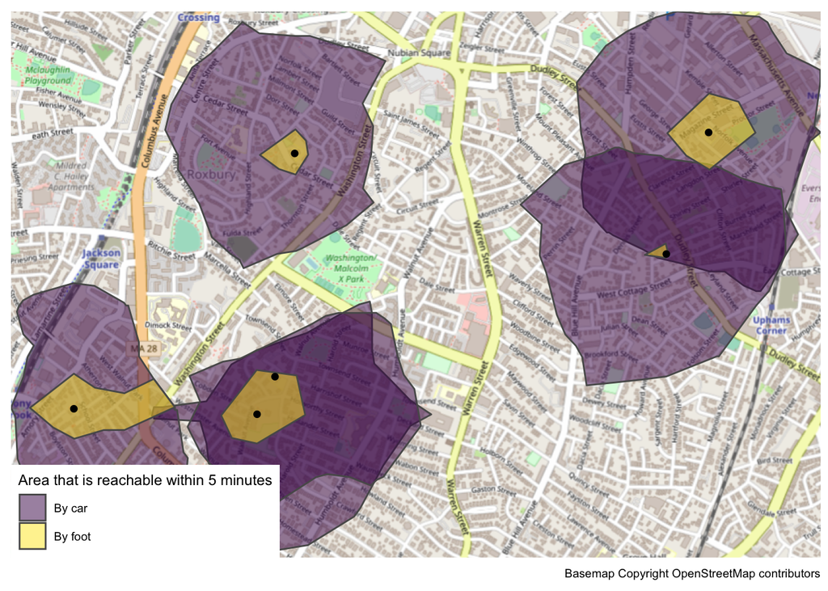

```r
right_side <- st_bbox(iso_all_modes)$xmax
left_side  <- st_bbox(iso_all_modes)$xmin
top_side <- st_bbox(iso_all_modes)$ymax
bottom_side <- st_bbox(iso_all_modes)$ymin
ggplot(iso_all_modes) +
  annotation_map_tile(zoomin = 0, progress = "none") +
  geom_sf(aes(fill = mode), alpha = 0.5) +
  geom_sf(data = Roxbury_Public) +
  coord_sf(xlim = c(left_side, right_side),
           ylim = c(bottom_side, top_side), expand = FALSE) +
  scale_fill_viridis_d(name = "Area that is reachable within 5 minutes",
                       labels = c("By car", "By foot")) +
  theme_map() +
  labs(caption = "Basemap Copyright OpenStreetMap contributors")
```

### Figure 2

I used Carole’s code to create this Scatter Plot that also compares the differences between walking and driving isochromes.

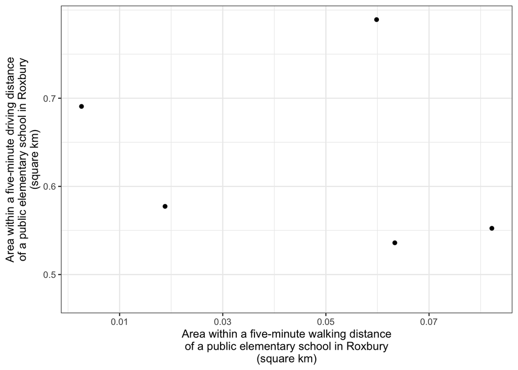

```r
iso_areas <- iso_all_modes %>%
  mutate(area = st_area(iso_all_modes)) %>%
  st_set_geometry(NULL) %>%
  pivot_wider(names_from = mode, values_from = area)
ggplot(iso_areas,
       aes(x = as.numeric(walk), y = as.numeric(drive))) +
  geom_point() +
  scale_x_continuous(name =
            "Area within a five-minute walking distance\nof a public elementary school in Roxbury\n(square km)",
            breaks = breaks <- seq(10000, 130000, by = 20000),
            labels = breaks / 1000000) +
  scale_y_continuous(name =
            "Area within a five-minute driving distance\nof a public elementary school in Roxbury\n(square km)",
            breaks = breaks <- seq(0, 700000, by = 100000),
            labels = breaks / 1000000) +
  theme_bw()
```

### Figure 3

I created this Boxplot after looking at Adrianna’s, Meghan’s, and Kristy’s work, and referring back to Assignment 2 that required us to make 10 different plots. I do think it is a little hard to interpret, but one thing that sticks out to me is that there is one school with a really small area within a 5 minute walking distance, so it is not that accesible via walking.

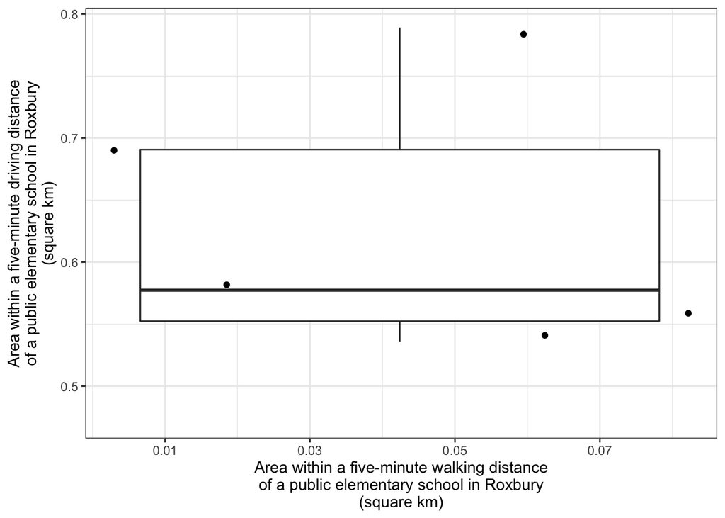

```r
iso_areas <- iso_all_modes %>%
  mutate(area = st_area(iso_all_modes)) %>%
  st_set_geometry(NULL) %>%
  pivot_wider(names_from = mode, values_from = area)
ggplot(iso_areas,
       aes(x = as.numeric(walk), y = as.numeric(drive))) +
  geom_boxplot() +
  geom_point(position = "jitter",
             size = 1.5,
             alpha = 1.5) +
  scale_x_continuous(name =
            "Area within a five-minute walking distance\nof a public elementary school in Roxbury\n(square km)",
            breaks = breaks <- seq(10000, 400000, by = 20000),
            labels = breaks / 1000000) +
  scale_y_continuous(name =
            "Area within a five-minute driving distance\nof a public elementary school in Roxbury\n(square km)",
            breaks = breaks <- seq(0, 1000000, by = 100000),
            labels = breaks / 1000000) +
  theme_bw()
```

### Why this is important

This was particularly interesting to me, because through my research for studio I have learned that Roxbury has had a lot of population growth over the past few years, with the largest increase in population being in young people ages 0-14.